# Busa 715 Final Project - FINAL - TEAM 3

## BOSTON HOUSING CLUSTERING PROJECT

### Objective

#### This project's objective is to assist individuals who are interested in buying or renting a home in Boston and those who want to make investment decisions in the housing market. To achieve this objective, we analyze the market dynamics in different towns and identify critical factors such as the number of rooms per dwelling, age of buildings, median home value, crime rate in the neighborhood, and accessibility to radial highways.

```python
# Import all the necessary packages
import numpy as np
import pandas as pd
import matplotlib.pyplot as plt
import seaborn as sns
import plotly.express as px

# Import machine learning and clustering algorithms
from sklearn.preprocessing import StandardScaler, LabelEncoder
from sklearn.decomposition import PCA
from sklearn.cluster import KMeans

from sklearn.cluster import AgglomerativeClustering
# to perform hierarchical clustering, compute cophenetic correlation, and create dendrograms
from sklearn.cluster import AgglomerativeClustering
from scipy.cluster.hierarchy import dendrogram, linkage, cophenet
# to compute distances
from scipy.spatial.distance import pdist

# Import utilities for computing distances
from scipy.spatial.distance import cdist

# To suppress warnings
import warnings
warnings.filterwarnings("ignore")
```

```python
df_1 = pd.read_csv("boston.csv")
```

```python
df = df_1.copy()
df.shape
```

```
(506, 13)
```

#### Boston dataset contains 506 rows and 13 columns

```python
df.head(5)
```

|  | CRIM | ZN | INDUS | CHAS | NX | RM | AGE | DIS | RAD | TAX | PTRATIO | LSTAT | MEDV |
| --- | --- | --- | --- | --- | --- | --- | --- | --- | --- | --- | --- | --- | --- |
| 0 | 0.00632 | 18.0 | 2.31 | 0 | 0.538 | 6.575 | 65.2 | 4.0900 | 1 | 296 | 15.3 | 4.98 | 24.0 |
| 1 | 0.02731 | 0.0 | 7.07 | 0 | 0.469 | 6.421 | 78.9 | 4.9671 | 2 | 242 | 17.8 | 9.14 | 21.6 |
| 2 | 0.02729 | 0.0 | 7.07 | 0 | 0.469 | 7.185 | 61.1 | 4.9671 | 2 | 242 | 17.8 | 4.03 | 34.7 |
| 3 | 0.03237 | 0.0 | 2.18 | 0 | 0.458 | 6.998 | 45.8 | 6.0622 | 3 | 222 | 18.7 | 2.94 | 33.4 |
| 4 | 0.06905 | 0.0 | 2.18 | 0 | 0.458 | 7.147 | 54.2 | 6.0622 | 3 | 222 | 18.7 | 5.33 | 36.2 |

#### Looking at the first 5 rows of our dataset

```python
df.info()
```

```
<class 'pandas.core.frame.DataFrame'>
RangeIndex: 506 entries, 0 to 505
Data columns (total 13 columns):
 #   Column   Non-Null Count  Dtype
---  ------   --------------  -----
 0   CRIM     506 non-null    float64
 1   ZN       506 non-null    float64
 2   INDUS    506 non-null    float64
 3   CHAS     506 non-null    int64
 4   NX       506 non-null    float64
 5   RM       506 non-null    float64
 6   AGE      506 non-null    float64
 7   DIS      506 non-null    float64
 8   RAD      506 non-null    int64
 9   TAX      506 non-null    int64
 10  PTRATIO  506 non-null    float64
 11  LSTAT    506 non-null    float64
 12  MEDV     506 non-null    float64
dtypes: float64(10), int64(3)
memory usage: 51.5 KB
```

#### Boston dataset contains 13 variables. All of them are numerical.

#### Variables names

• CRIM: per capita crime rate by town

• ZN: proportion of residential land zoned for lots over 25,000 sq. ft.

• INDUS: proportion of non-retail business acres per town

• CHAS: Charles River dummy variable (= 1 if tract bounds river; 0 otherwise)

• NOX: nitric oxides concentration (parts per 10 million)

• RM: average number of rooms per dwelling

• AGE: proportion of owner-occupied units built prior to 1940

• DIS: weighted distances to five Boston employment centers

• RAD: index of accessibility to radial highways

• TAX: full-value property-tax rate per 10,000 dollars

• PTRATIO: pupil-teacher ratio by town

• LSTAT: %lower status of the population

• MEDV: Median value of owner-occupied homes in 1000 dollars.

```python
df.describe()
```

|  | CRIM | ZN | INDUS | CHAS | NX | RM | AGE | DIS | RAD | TAX | PTRATIO | LSTAT | MEDV |
| --- | --- | --- | --- | --- | --- | --- | --- | --- | --- | --- | --- | --- | --- |
| count | 506.000000 | 506.000000 | 506.000000 | 506.000000 | 506.000000 | 506.000000 | 506.000000 | 506.000000 | 506.000000 | 506.000000 | 506.000000 | 506.000000 | 506.000000 |
| mean | 3.613524 | 11.363636 | 11.136779 | 0.069170 | 0.554695 | 6.284634 | 68.574901 | 3.795043 | 9.549407 | 408.237154 | 18.455534 | 12.653063 | 22.532806 |
| std | 8.601545 | 23.322453 | 6.860353 | 0.253994 | 0.115878 | 0.702617 | 28.148861 | 2.105710 | 8.707259 | 168.537116 | 2.164946 | 7.141062 | 9.197104 |
| min | 0.006320 | 0.000000 | 0.460000 | 0.000000 | 0.385000 | 3.561000 | 2.900000 | 1.129600 | 1.000000 | 187.000000 | 12.600000 | 1.730000 | 5.000000 |
| 25% | 0.082045 | 0.000000 | 5.190000 | 0.000000 | 0.449000 | 5.885500 | 45.025000 | 2.100175 | 4.000000 | 279.000000 | 17.400000 | 6.950000 | 17.025000 |
| 50% | 0.256510 | 0.000000 | 9.690000 | 0.000000 | 0.538000 | 6.208500 | 77.500000 | 3.207450 | 5.000000 | 330.000000 | 19.050000 | 11.360000 | 21.200000 |
| 75% | 3.677083 | 12.500000 | 18.100000 | 0.000000 | 0.624000 | 6.623500 | 94.075000 | 5.188425 | 24.000000 | 666.000000 | 20.200000 | 16.955000 | 25.000000 |
| max | 88.976200 | 100.000000 | 27.740000 | 1.000000 | 0.871000 | 8.780000 | 100.000000 | 12.126500 | 24.000000 | 711.000000 | 22.000000 | 37.970000 | 50.000000 |

```python
# dropping/ignoring object variable columns
df = df.drop(columns=["CHAS"])
```

#### Dropping the variable CHAS ( Charles River dummy variable (= 1 if tract bounds river; 0 otherwise) because it doesn't add any value to the clusterong process.

```python
# checking for missing values
df.isnull().sum()
```

```
CRIM       0
ZN         0
INDUS      0
NX         0
RM         0
AGE        0
DIS        0
RAD        0
TAX        0
PTRATIO    0
LSTAT      0
MEDV       0
dtype: int64
```

#### There are no missing values in the Boston Houses dataset.

```python
df.duplicated().sum()
```

```
0
```

#### There are no duplicates in our dateset.

# EDA

### Vizualizing the relationship between the variables.

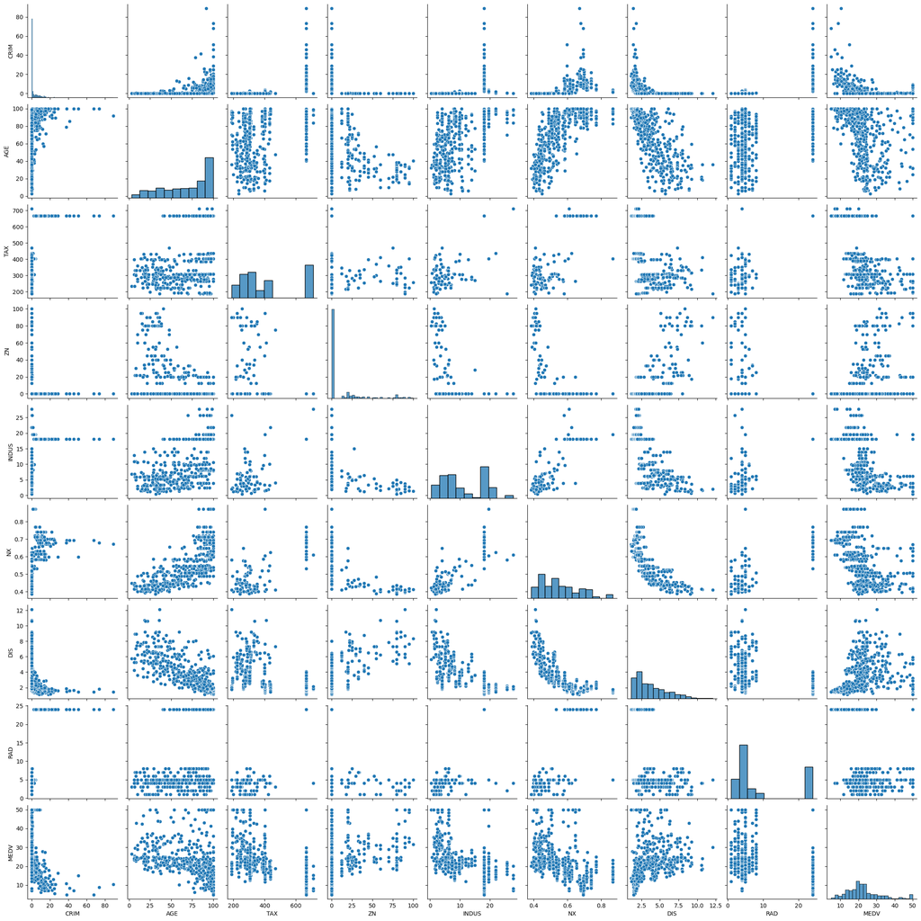

```python
sns.pairplot(df[['CRIM', 'AGE', 'TAX', 'ZN', 'INDUS', 'NX', 'DIS','RAD', 'MEDV']]);
```

```
CRIM
Skew : 5.22
```

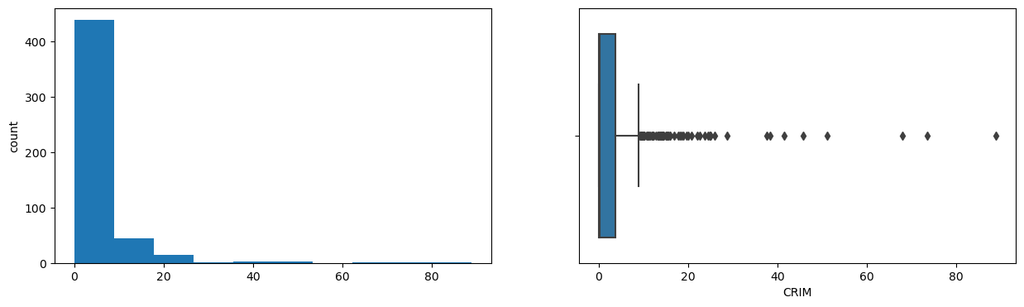

```
ZN
Skew : 2.23
```

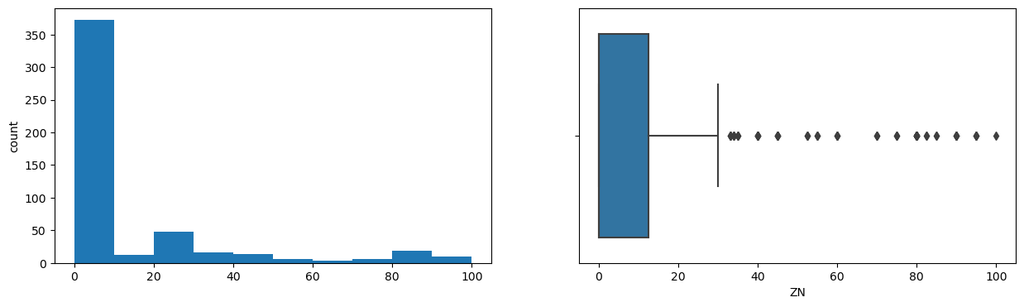

```
INDUS
Skew : 0.3
```

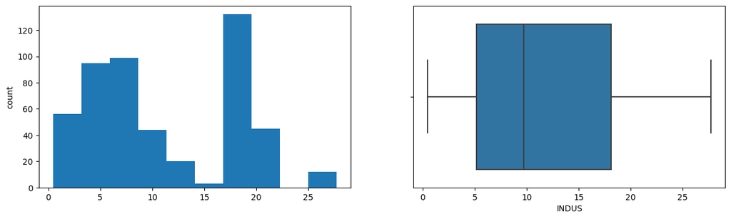

```
NX
Skew : 0.73
```

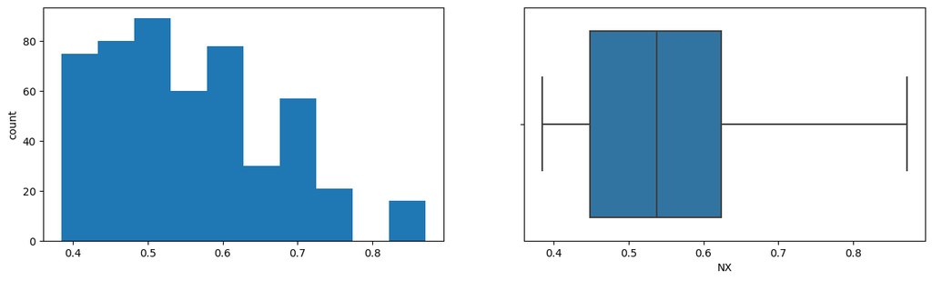

```
RM
Skew : 0.4
```

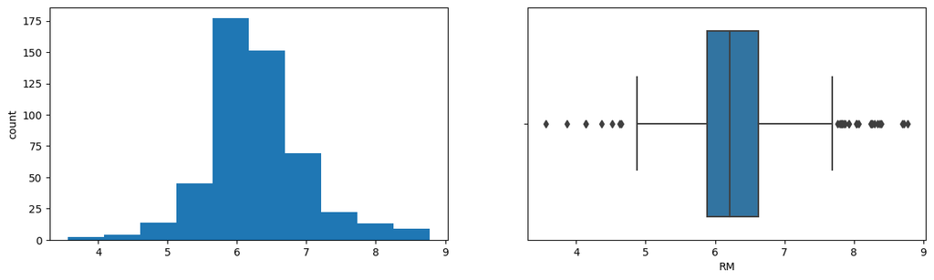

```
AGE
Skew : -0.6
```

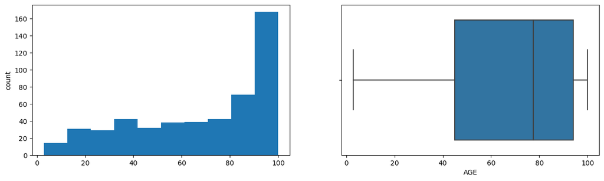

```
DIS
Skew : 1.01
```

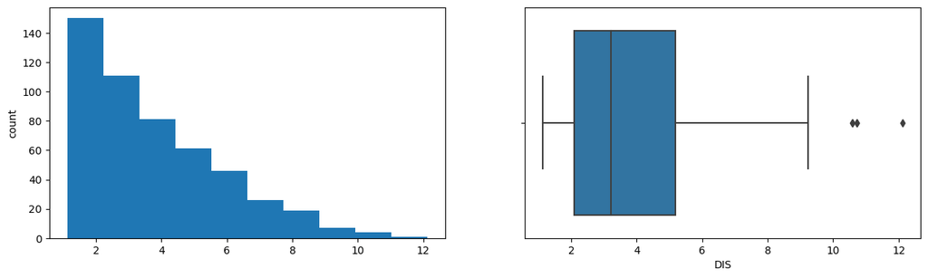

```
RAD
Skew : 1.0
```

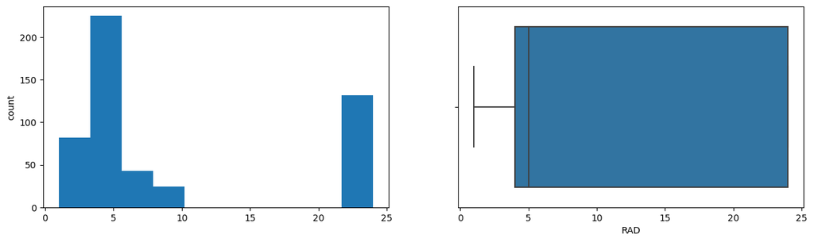

```
TAX
Skew : 0.67
```

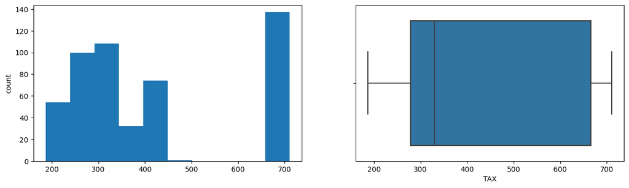

```
PTRATIO
Skew : -0.8
```

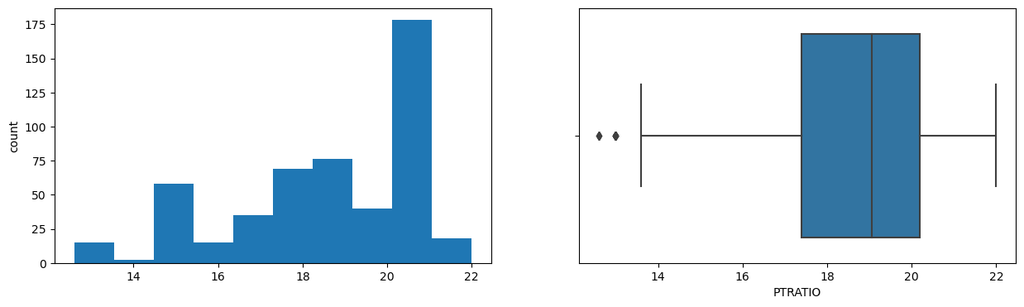

```
LSTAT
Skew : 0.91
```

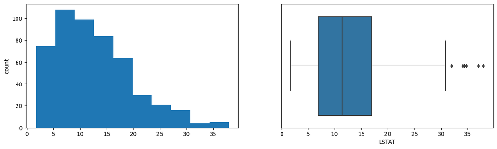

```
MEDV
Skew : 1.11
```

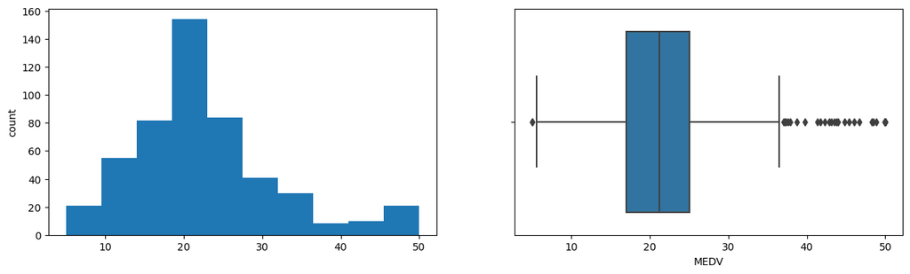

```python
df_numeric = df.select_dtypes(include=['number'])

# Loop through numeric columns
for col in df_numeric.columns:
    print(col)
    print("Skew :", round(df_numeric[col].skew(), 2))
    plt.figure(figsize=(15, 4))
    plt.subplot(1, 2, 1)
    df_numeric[col].hist(bins=10, grid=False)
    plt.ylabel("count")
    plt.subplot(1, 2, 2)
    sns.boxplot(x=df_numeric[col])
    plt.show()
```

### EDA Analysis

#### The average pupil-teacher ratio by town (TRATIO) is 18.46, which is favorable as it falls below the desired level of less than 30. In summary, it can be concluded that education standards are generally satisfactory in most of these towns.This particular variable holds significance for families with children when determining their relocation choices.

#### The plot for LSTAT: %lower status of the population shows a notable variability of the status of the residents from these towns. However, the wide range suggests that there are areas with significantly lower socioeconomic status, potentially impacting various socio-economic factors within these towns.

#### The distribution of MEDV appears to be slightly skewed to the right, resembling a nearly normal distribution. The average value of owner-occupied homes, measured in thousands of dollars, is approximately 23. Additionally, the plot indicates some outliers, further confirming the observed right-skewed distribution.

### Heat Map

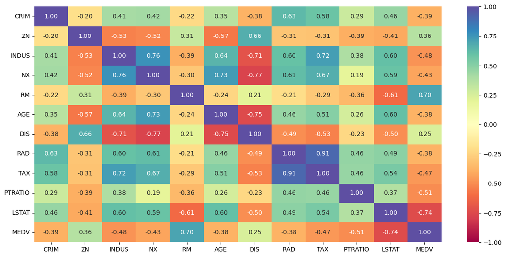

```python
# generating a heatmap
plt.figure(figsize=(15, 7))
sns.heatmap(df.corr(), annot=True, vmin=-1, vmax=1, fmt=".2f", cmap="Spectral")
plt.show()
```

#### As we can see on the above heat map, the following variables are positively correlated.

#### -RM & MEDV

#### -TAX & INDUS

#### -NX &INDUS

#### Below we can see the other variables that has high negative correlation.

#### -DIS &NX

#### -DIS & INDUS

#### -AGE & DIS

#### -LSTAT & MEDV

# Normalizing the data

```python
scaler=StandardScaler()
df_scaled=pd.DataFrame(scaler.fit_transform(df), columns=df.columns)
```

#### We aim to assess clusters ranging from 1 to 9. Our goal is to determine the ideal cluster count by plotting the mean distortion for each scenario.

# Hierarchical Clustering Method

```python
df_scaled.head()
```

|  | CRIM | ZN | INDUS | NX | RM | AGE | DIS | RAD | TAX | PTRATIO | LSTAT | MEDV |
| --- | --- | --- | --- | --- | --- | --- | --- | --- | --- | --- | --- | --- |
| 0 | -0.419782 | 0.284830 | -1.287909 | -0.144217 | 0.413672 | -0.120013 | 0.140214 | -0.982843 | -0.666608 | -1.459000 | -1.075562 | 0.159686 |
| 1 | -0.417339 | -0.487722 | -0.593381 | -0.740262 | 0.194274 | 0.367166 | 0.557160 | -0.867883 | -0.987329 | -0.303094 | -0.492439 | -0.101524 |
| 2 | -0.417342 | -0.487722 | -0.593381 | -0.740262 | 1.282714 | -0.265812 | 0.557160 | -0.867883 | -0.987329 | -0.303094 | -1.208727 | 1.324247 |
| 3 | -0.416750 | -0.487722 | -1.306878 | -0.835284 | 1.016303 | -0.809889 | 1.077737 | -0.752922 | -1.106115 | 0.113032 | -1.361517 | 1.182758 |
| 4 | -0.412482 | -0.487722 | -1.306878 | -0.835284 | 1.228577 | -0.511180 | 1.077737 | -0.752922 | -1.106115 | 0.113032 | -1.026501 | 1.487503 |

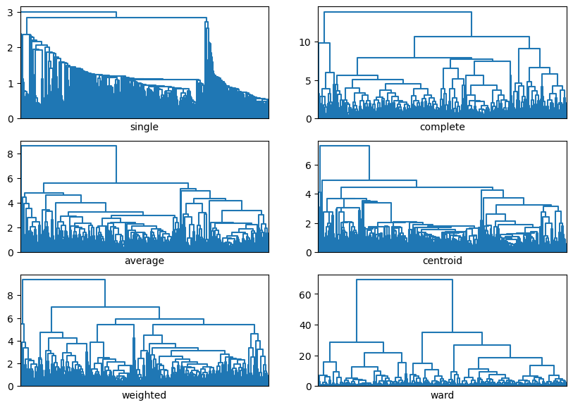

```python
#Plotting all the linkage methods together
fig, axes = plt.subplots(nrows=3, ncols=2, figsize=(10, 7), squeeze=False)
for i, method in enumerate(
    ["single", "complete", "average", "centroid", "weighted", "ward"]
):
    ax = axes[i // 2, i % 2]
    Z = linkage(df_scaled, method=method)
    dendrogram(Z, color_threshold=0, ax=ax, no_labels=True)
    ax.set_xlabel(method)
```

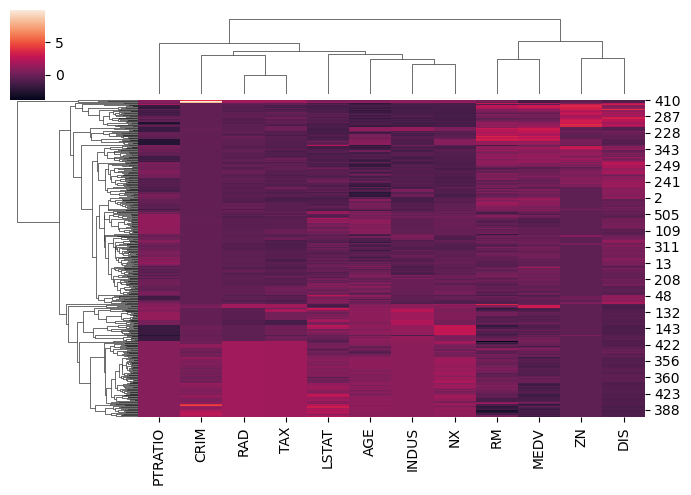

```python
#plotting clustermap
sns.clustermap(df_scaled, figsize=(7, 5))
```

```python
# list of distance metrics
distance_metrics = ["euclidean", "chebyshev", "mahalanobis", "cityblock"]
# list of linkage methods
linkage_methods = ["single", "complete", "average", "weighted"]

high_cophenet_corr = 0
high_dm_lm = [0, 0]

for dm in distance_metrics:
    for lm in linkage_methods:
        Z = linkage(df_scaled, metric=dm, method=lm)
        c, coph_dists = cophenet(Z, pdist(df_scaled))
        print(
            "Cophenetic correlation for {} distance and {} linkage is {}.".format(
                dm.capitalize(), lm, c
            )
        )
        if high_cophenet_corr < c:
            high_cophenet_corr = c
            high_dm_lm[0] = dm
            high_dm_lm[1] = lm
```

```
Cophenetic correlation for Euclidean distance and single linkage is 0.6815350866046702.
Cophenetic correlation for Euclidean distance and complete linkage is 0.6611326458123762.
Cophenetic correlation for Euclidean distance and average linkage is 0.7618464374842046.
Cophenetic correlation for Euclidean distance and weighted linkage is 0.6312319420563697.
Cophenetic correlation for Chebyshev distance and single linkage is 0.6583360660532448.
Cophenetic correlation for Chebyshev distance and complete linkage is 0.6563949319262988.
Cophenetic correlation for Chebyshev distance and average linkage is 0.7146540225035618.
Cophenetic correlation for Chebyshev distance and weighted linkage is 0.6711263734816916.
Cophenetic correlation for Mahalanobis distance and single linkage is 0.546823190671611.
Cophenetic correlation for Mahalanobis distance and complete linkage is 0.49918400076229064.
Cophenetic correlation for Mahalanobis distance and average linkage is 0.5442512916919185.
Cophenetic correlation for Mahalanobis distance and weighted linkage is 0.537202964028419.
Cophenetic correlation for Cityblock distance and single linkage is 0.6684559138429924.
Cophenetic correlation for Cityblock distance and complete linkage is 0.6747832973856664.
Cophenetic correlation for Cityblock distance and average linkage is 0.7018710512146834.
Cophenetic correlation for Cityblock distance and weighted linkage is 0.6708831560186942.
```

```python
# printing the combination of distance metric and linkage method with the highest cophenetic correlation
print("Highest cophenetic correlation is {}, which is obtained with {} distance and {} linkage.".format(high_cophenet_corr, high_dm_lm[0], high_dm_lm[1]))
```

```
Highest cophenetic correlation is 0.7618464374842046, which is obtained with euclidean distance and average linkage.
```

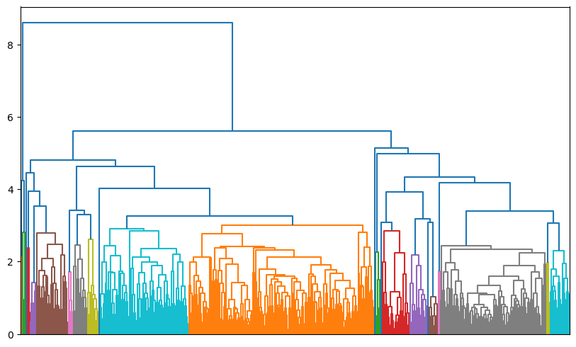

```python
# Hierarchical clustering using complete linkage and Euclidean distance
Z = linkage(df_scaled, method="average", metric="euclidean")
fig = plt.figure(figsize=(10, 6))
dendrogram(Z, no_labels=True, color_threshold=3)
plt.show()
```

[output not shown]

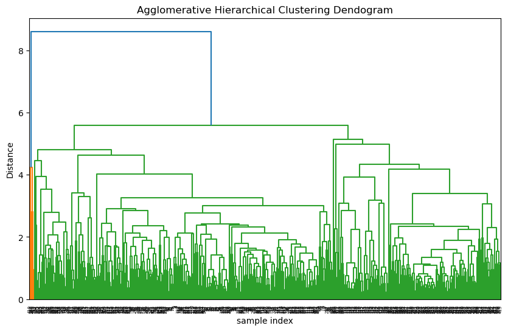

```python
# Let us visualze the dendrogram
plt.figure(figsize=(10, 6))
plt.title("Agglomerative Hierarchical Clustering Dendogram")
plt.xlabel("sample index")
plt.ylabel("Distance")
dendrogram(Z,leaf_rotation=90.0, leaf_font_size=5.0)
plt.tight_layout
plt.show
```

# Choosing 5 cluster after cutting of distance at 4.4.

```python
#Initializing the model
HCmodel = AgglomerativeClustering(n_clusters=5, affinity="euclidean", linkage="average")
HCmodel.fit(df_scaled)
```

```
AgglomerativeClustering(affinity='euclidean', linkage='average', n_clusters=5)
```

```python
# adding hierarchical cluster labels to the original dataframes
df["HC_Clusters"] = HCmodel.labels_
```

```python
df.sample(5)
```

|  | CRIM | ZN | INDUS | NX | RM | AGE | DIS | RAD | TAX | PTRATIO | LSTAT | MEDV | HC_Clusters |
| --- | --- | --- | --- | --- | --- | --- | --- | --- | --- | --- | --- | --- | --- |
| 234 | 0.44791 | 0.0 | 6.20 | 0.507 | 6.726 | 66.5 | 3.6519 | 8 | 307 | 17.4 | 8.05 | 29.0 | 0 |
| 302 | 0.09266 | 34.0 | 6.09 | 0.433 | 6.495 | 18.4 | 5.4917 | 7 | 329 | 16.1 | 8.67 | 26.4 | 0 |
| 386 | 24.39380 | 0.0 | 18.10 | 0.700 | 4.652 | 100.0 | 1.4672 | 24 | 666 | 20.2 | 28.28 | 10.5 | 2 |
| 83 | 0.03551 | 25.0 | 4.86 | 0.426 | 6.167 | 46.7 | 5.4007 | 4 | 281 | 19.0 | 7.51 | 22.9 | 0 |
| 425 | 15.86030 | 0.0 | 18.10 | 0.679 | 5.896 | 95.4 | 1.9096 | 24 | 666 | 20.2 | 24.39 | 8.3 | 2 |

```python
cluster_profile_HC = df.groupby("HC_Clusters").mean()
```

```python
cluster_profile_HC["count_in_each_segments"] = (
    df.groupby("HC_Clusters")["MEDV"].count().values
)
```

```python
# let's display cluster profiles
cluster_profile_HC.style.highlight_max(color="pink", axis=0)
```

| HC_Clusters | CRIM | ZN | INDUS | NX | RM | AGE | DIS | RAD | TAX | PTRATIO | LSTAT | MEDV | count_in_each_segments |
| --- | --- | --- | --- | --- | --- | --- | --- | --- | --- | --- | --- | --- | --- |
| 0 | 0.241577 | 17.850467 | 6.560561 | 0.484164 | 6.466798 | 55.610592 | 4.823474 | 4.485981 | 301.841121 | 17.879751 | 9.427664 | 25.822118 | 321 |
| 1 | 63.845760 | 0.000000 | 18.100000 | 0.663800 | 6.113400 | 94.120000 | 1.584080 | 24.000000 | 666.000000 | 20.200000 | 17.088000 | 10.020000 | 5 |
| 2 | 8.009121 | 0.114943 | 19.138908 | 0.678333 | 5.942966 | 90.864943 | 2.045639 | 17.977011 | 588.224138 | 19.407471 | 18.718851 | 16.038506 | 174 |
| 3 | 3.474280 | 0.000000 | 18.100000 | 0.718000 | 8.780000 | 82.900000 | 1.904700 | 24.000000 | 666.000000 | 20.200000 | 5.290000 | 21.900000 | 1 |
| 4 | 6.921302 | 0.000000 | 18.100000 | 0.638400 | 6.152000 | 96.780000 | 1.238060 | 24.000000 | 666.000000 | 20.200000 | 5.672000 | 50.000000 | 5 |

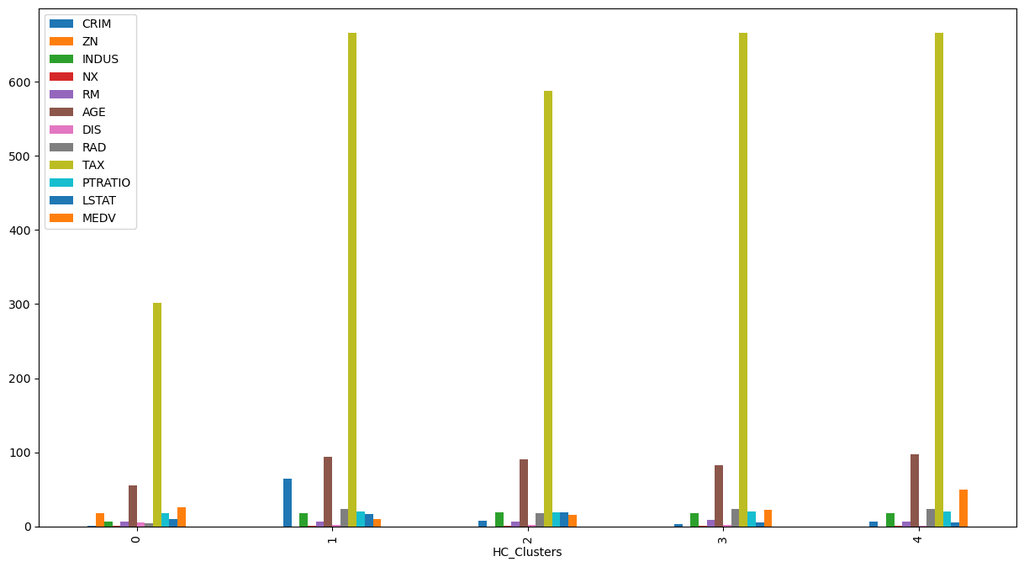

```python
# plotting of mean of every variable in each cluster
df.groupby("HC_Clusters").mean().plot.bar(figsize=(15, 8))
```

### Analysis

# K-Means

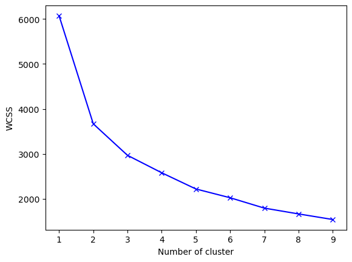

```python
# step 1
WCSS = {}

# step 2 - iterate for a range of Ks and fit the scaled data to the algorithm. Use inertia attribute from the clustering object and
# store the inertia value for that k
for k in range(1, 10):
    kmeans = KMeans(n_clusters=k, max_iter=1000).fit(df_scaled)
    WCSS[k] = kmeans.inertia_

# step 3
plt.figure()
plt.plot(list(WCSS.keys()), list(WCSS.values()), 'bx-')
plt.xlabel("Number of cluster")
plt.ylabel("WCSS")
plt.show()
```

#### Visual inspection suggests elbow at 3 clusters. Let us use Knee Locator

```python
# Uncomment the following code to install kneed
!pip install kneed
```

```python
from kneed import KneeLocator #importing kneelocator from kneed library
```

```python
k_values = list(WCSS.keys())
wcss_values = list(WCSS.values())
k1 = KneeLocator(k_values, wcss_values, curve="convex", direction="decreasing")

# Find the elbow point
elbow_point = k1.elbow
print("Elbow point at:", elbow_point)
```

```
Elbow point at: 3
```

# Using the Silhouette method

```python
from sklearn.metrics import silhouette_score

silhouette_coefficients = []
for k in range (2, 11):
    kmeans = KMeans (n_clusters = k, random_state=42)
    kmeans.fit (df_scaled)
    score = silhouette_score (df_scaled, kmeans.labels_)
    silhouette_coefficients.append (score)
# using the silhouette method
```

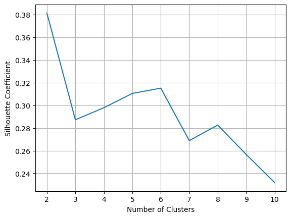

```python
# Plotting the results:
plt.plot (range (2, 11), silhouette_coefficients)
plt.xticks (range (2, 11))
plt.xlabel ("Number of Clusters")
plt.ylabel ("Silhouette Coefficient")
plt.grid(True)
plt.show ()
```

```python
kmeans = KMeans(n_clusters=3, random_state=1)  # initializing the model
kmeans.fit(df_scaled)
```

```
KMeans(n_clusters=3, random_state=1)
```

```python
#Adding labels to scaled and original data
df_scaled["kmeans_clusters"] = kmeans.labels_
df['kmeans_clusters'] = kmeans.labels_
```

```python
df_scaled.head()#displaying the scaled features of the dataset
```

|  | CRIM | ZN | INDUS | NX | RM | AGE | DIS | RAD | TAX | PTRATIO | LSTAT | MEDV | kmeans_clusters |
| --- | --- | --- | --- | --- | --- | --- | --- | --- | --- | --- | --- | --- | --- |
| 0 | -0.419782 | 0.284830 | -1.287909 | -0.144217 | 0.413672 | -0.120013 | 0.140214 | -0.982843 | -0.666608 | -1.459000 | -1.075562 | 0.159686 | 2 |
| 1 | -0.417339 | -0.487722 | -0.593381 | -0.740262 | 0.194274 | 0.367166 | 0.557160 | -0.867883 | -0.987329 | -0.303094 | -0.492439 | -0.101524 | 2 |
| 2 | -0.417342 | -0.487722 | -0.593381 | -0.740262 | 1.282714 | -0.265812 | 0.557160 | -0.867883 | -0.987329 | -0.303094 | -1.208727 | 1.324247 | 2 |
| 3 | -0.416750 | -0.487722 | -1.306878 | -0.835284 | 1.016303 | -0.809889 | 1.077737 | -0.752922 | -1.106115 | 0.113032 | -1.361517 | 1.182758 | 0 |
| 4 | -0.412482 | -0.487722 | -1.306878 | -0.835284 | 1.228577 | -0.511180 | 1.077737 | -0.752922 | -1.106115 | 0.113032 | -1.026501 | 1.487503 | 0 |

#### The rows from the above data belong to clusters 0 & 2.

#### Visualizing the clusters based on "Crime rate and Median value of owner-occupied homes."

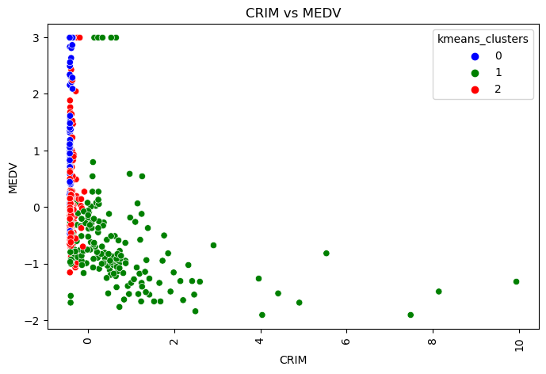

```python
fig = plt.figure(figsize=(8,5), dpi=100)
sns.scatterplot(x='CRIM', y='MEDV', data=df_scaled, hue='kmeans_clusters', palette=['blue', 'green', 'red'])
plt.title('CRIM vs MEDV', fontsize=12)
plt.xticks(rotation=90, fontsize=10)
plt.yticks(fontsize=10)
plt.xlabel('CRIM', fontsize=10)
plt.ylabel('MEDV', fontsize=10)
plt.show()
```

#### Visualizing the clusters based on "Number of rooms and Median value of owner-occupied homes."

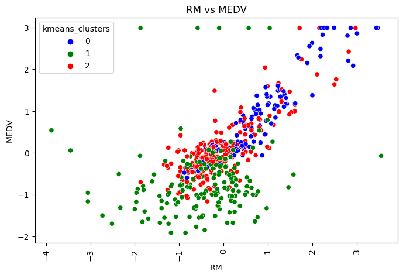

```python
fig = plt.figure(figsize=(8,5), dpi=100)
sns.scatterplot(x='RM', y='MEDV', data=df_scaled, hue='kmeans_clusters', palette=['blue', 'green', 'red'])
plt.title('RM vs MEDV', fontsize=12)
plt.xticks(rotation=90, fontsize=10)
plt.yticks(fontsize=10)
plt.xlabel('RM', fontsize=10)
plt.ylabel('MEDV', fontsize=10)
plt.show()
```

#### Visualizing the clusters based on "Age and Median value of owner-occupied homes."

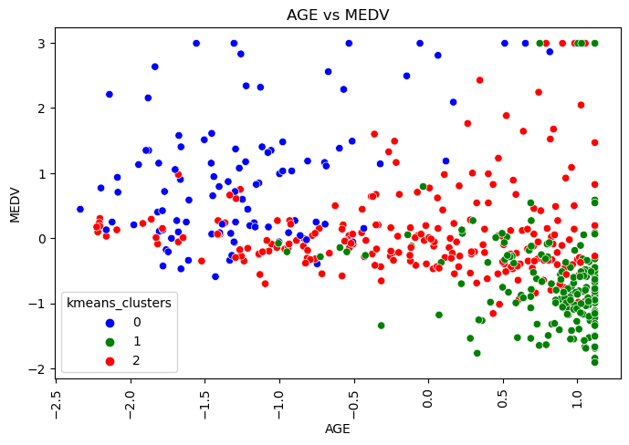

```python
fig = plt.figure(figsize=(8,5), dpi=100)
sns.scatterplot(x='AGE', y='MEDV', data=df_scaled, hue='kmeans_clusters', palette=['blue', 'green', 'red'])
plt.title('AGE vs MEDV', fontsize=12)
plt.xticks(rotation=90, fontsize=10)
plt.yticks(fontsize=10)
plt.xlabel('AGE', fontsize=10)
plt.ylabel('MEDV', fontsize=10)
plt.show()
```

#### Visualizing the clusters based on "Distance to employment centers and Median value of owner-occupied homes."

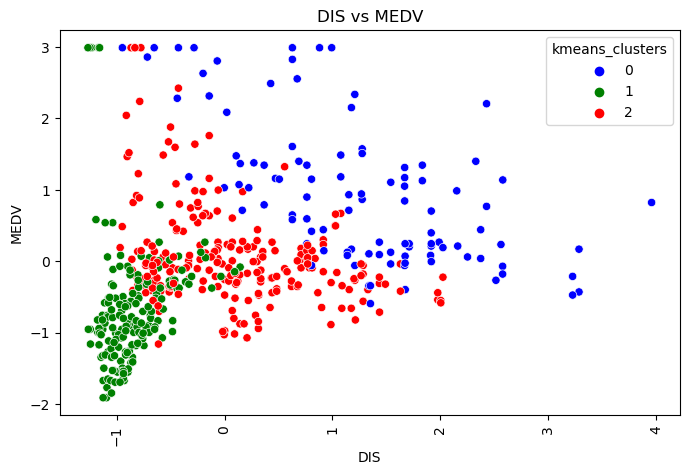

```python
fig = plt.figure(figsize=(8,5), dpi=100)
sns.scatterplot(x='DIS', y='MEDV', data=df_scaled, hue='kmeans_clusters', palette=['blue', 'green', 'red'])
plt.title('DIS vs MEDV', fontsize=12)
plt.xticks(rotation=90, fontsize=10)
plt.yticks(fontsize=10)
plt.xlabel('DIS', fontsize=10)
plt.ylabel('MEDV', fontsize=10)
plt.show()
```

```python
cluster_profile = df_scaled.groupby("kmeans_clusters").mean()
```

```python
cluster_profile["count_in_each_segment"] = (
    df_scaled.groupby("kmeans_clusters")["AGE"].count().values
)
```

```python
#Number of observations in each cluster
df_scaled.kmeans_clusters.value_counts ()
```

```
2    234
1    169
0    103
Name: kmeans_clusters, dtype: int64
```

#### There are 234 occurrences in cluster 2, 169 occurrences in cluster 1, and 103 occurrences in cluster 0.

```python
# let's display cluster profiles
cluster_profile.style.highlight_max(color="yellow", axis=0)
```

| kmeans_clusters | CRIM | ZN | INDUS | NX | RM | AGE | DIS | RAD | TAX | PTRATIO | LSTAT | MEDV | count_in_each_segment |
| --- | --- | --- | --- | --- | --- | --- | --- | --- | --- | --- | --- | --- | --- |
| 0 | -0.408724 | 1.566166 | -1.072204 | -1.020572 | 0.882689 | -1.215935 | 1.244068 | -0.601130 | -0.659804 | -0.734932 | -0.946262 | 0.946063 | 103 |
| 1 | 0.771881 | -0.487722 | 1.133659 | 1.121323 | -0.452352 | 0.805529 | -0.854376 | 1.167392 | 1.253432 | 0.602480 | 0.853138 | -0.672245 | 169 |
| 2 | -0.377561 | -0.337137 | -0.346800 | -0.360619 | -0.061835 | -0.046552 | 0.069446 | -0.578516 | -0.614830 | -0.111629 | -0.199638 | 0.069081 | 234 |

#### Cluster 0 has the highest average values in ZN, RM, DIS, MEDV. Cluster 1 has the highest average values in CRIM, INDUS, NX, AGE, RAD, TAX, PTRATIO, LSTAT.Cluster 2 has the highest average values in count in each segment.

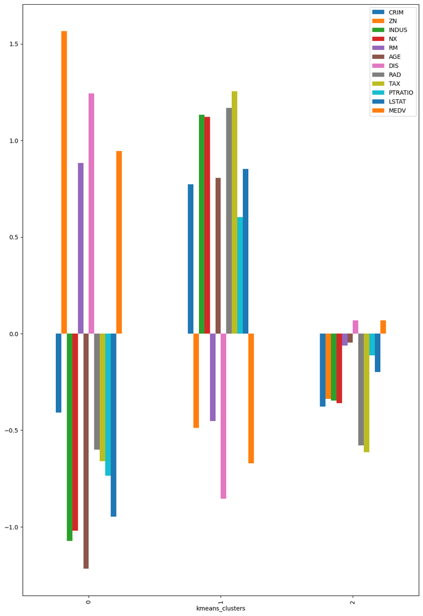

```python
# plotting means in scaled data
df_scaled.groupby("kmeans_clusters").mean().plot.bar(figsize=(12, 18))
```

### Analsyis

#### Cluster 0 represents areas with higher median home values, lower crime rates, and lower variables indicating lower socioeconomic status of the population, suggesting more affluent neighborhoods.

# K-Means with PCA

```python
pca=PCA()
pca.fit(df_scaled)
print(pca.components_)
```

```
[[ 2.40398696e-01 -2.58150906e-01  3.38279691e-01  3.30313765e-01
  -2.11745387e-01  3.06230095e-01 -3.06859786e-01  3.02341015e-01
   3.24204585e-01  2.13673445e-01  3.16847850e-01 -2.71300006e-01
   5.54890880e-02]
 [ 3.25546621e-01  3.73978389e-01  3.94931582e-02  8.01984102e-02
   3.56896725e-01 -9.49294269e-02  4.67620479e-02  4.08379070e-01
   3.64393725e-01 -6.58362401e-02 -1.31706845e-01  2.26642913e-01
  -4.84757821e-01]
 [-1.46887974e-01 -2.70197227e-01  1.16304216e-01  2.53663849e-01
   4.24885772e-01  3.12774108e-01 -4.19478518e-01 -6.78645728e-02
  -7.86382967e-02 -3.27842868e-01 -2.06009704e-01  4.37811413e-01
   1.44354475e-01]
 [ 1.40532946e-02  3.57329865e-01  6.25194874e-02  2.62158521e-01
  -2.64054940e-01  1.16727058e-01 -1.01739769e-03 -2.00658191e-01
  -9.29194602e-02 -7.11756205e-01  3.30802574e-01 -1.37127862e-01
  -1.80005051e-01]
 [ 8.22376093e-01 -1.39188236e-01 -3.47145324e-01 -1.68144163e-01
   9.07204951e-02  5.46245904e-02 -4.91067985e-02 -3.06866115e-02
  -2.05333521e-01 -1.68537385e-01  6.08003246e-02 -1.86385540e-02
   2.57611882e-01]
 [ 1.02996457e-01 -2.78429633e-01  1.86995455e-01  6.22672108e-02
  -4.55154902e-01 -5.82229160e-01 -8.22101432e-02  1.52510956e-01
   1.56321829e-01 -3.17478541e-01 -3.64336223e-01  1.60775060e-01
   1.14151844e-01]
 [ 3.05434815e-01  2.03778755e-01  4.91976575e-01 -5.26456936e-02
  -1.34023977e-01 -5.88404980e-02 -2.72078862e-01 -4.78561633e-01
  -2.76475428e-01  3.24760106e-01 -9.82407838e-02  1.96991018e-01
  -2.55996090e-01]
 [-6.97179326e-02  2.51555539e-01 -3.19091804e-01 -1.89310990e-01
  -5.31726021e-01  3.28144734e-01 -2.03023513e-01  2.06101647e-01
   5.94378247e-02  1.15081333e-01  4.83252816e-02  5.45417992e-01
   5.91636694e-02]
 [-1.03431187e-01 -2.97559148e-01 -6.15972055e-02 -2.05230775e-01
   1.29842200e-01 -4.01798851e-01 -2.22936034e-01  5.82546777e-02
  -8.98140425e-02 -1.28042002e-02  6.89779264e-01  2.60465205e-01
  -2.67550359e-01]
 [ 1.40230895e-02  5.51232847e-02  5.39127751e-01 -6.13622583e-01
   9.15900661e-02  1.72796666e-01  2.38941941e-01  3.77945966e-02
   2.32954844e-01 -2.27333860e-01  1.48721509e-01  1.15391106e-01
   3.02361408e-01]
 [ 1.06029728e-01 -4.69857041e-01  7.10847584e-02  1.48483335e-01
  -1.65398011e-01  2.88213823e-01  6.28427422e-01 -3.52627982e-02
  -1.25313085e-01 -1.47575269e-03  7.63644633e-04  2.89692750e-01
  -3.66981599e-01]
 [ 5.42109370e-02  2.77533820e-01  1.51090748e-01  4.70594686e-01
   9.00498643e-02 -2.31433747e-01  3.09804975e-01  1.28316693e-01
  -1.93611162e-01  1.77911793e-01  2.67208857e-01  3.29927163e-01
   5.02238123e-01]
 [ 6.57022244e-02 -4.16415877e-02 -2.11895430e-01  1.35903286e-01
   2.70423950e-02 -6.86518871e-02  7.46847151e-02 -6.15399116e-01
   6.96561220e-01  6.72434173e-02  1.12479250e-01  1.67729238e-01
   1.01674375e-01]]
```

```python
print(pca.explained_variance_ratio_)
```

```
[0.50328258 0.12578412 0.12028787 0.06800867 0.04633135 0.03257222
 0.02344652 0.0209762  0.01749226 0.0158891  0.0126145  0.00857299
 0.00474163]
```

```python
print(np.cumsum(pca.explained_variance_ratio_))
```

```
[0.50328258 0.62906669 0.74935456 0.81736323 0.86369459 0.89626681
 0.91971332 0.94068952 0.95818178 0.97407088 0.98668537 0.99525837
 1.        ]
```

### Scree plot to display eigen values

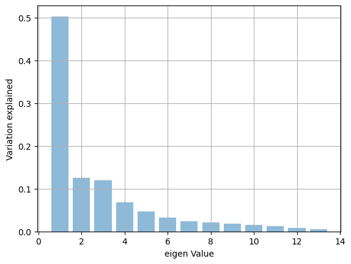

```python
plt.bar(list(range(1,14)),pca.explained_variance_ratio_,alpha=0.5, align='center')
plt.ylabel('Variation explained')
plt.xlabel('eigen Value')
plt.grid(True)
plt.show()
```

### Cumulative explained variance plot

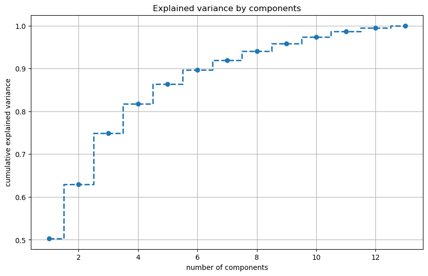

```python
fig = plt.figure(figsize=(10,6))
plt.step(list(range(1,14)),pca.explained_variance_ratio_.cumsum(),  where="mid",marker="o", linestyle = "--", linewidth=2)
plt.title('Explained variance by components')
plt.xlabel('number of components')
plt.ylabel("cumulative explained variance")
plt.grid(True)
plt.show()
```

#### We opted to utilize five principal components to ensure they collectively account for at least 85% of the variance.

```python
pca=PCA(n_components=5, random_state=1)
pca5_df = pd.DataFrame(pca.fit_transform(df_scaled), columns=["PC1" , "PC2" , "PC3", "PC4", "PC5"])
```

```python
pca5_df.head()
```

|  | PC1 | PC2 | PC3 | PC4 | PC5 |
| --- | --- | --- | --- | --- | --- |
| 0 | -1.993135 | -0.656612 | 0.873653 | 0.640678 | 0.646045 |
| 1 | -1.253957 | -1.352185 | 0.299849 | -0.221077 | 0.508773 |
| 2 | -2.292032 | -0.486156 | 1.336114 | -1.014833 | 0.502814 |
| 3 | -2.870426 | 0.392986 | 0.273140 | -1.057376 | 0.116365 |
| 4 | -2.799402 | 0.466724 | 0.520538 | -1.009465 | 0.170139 |

### Heat Map for the 5 principals components

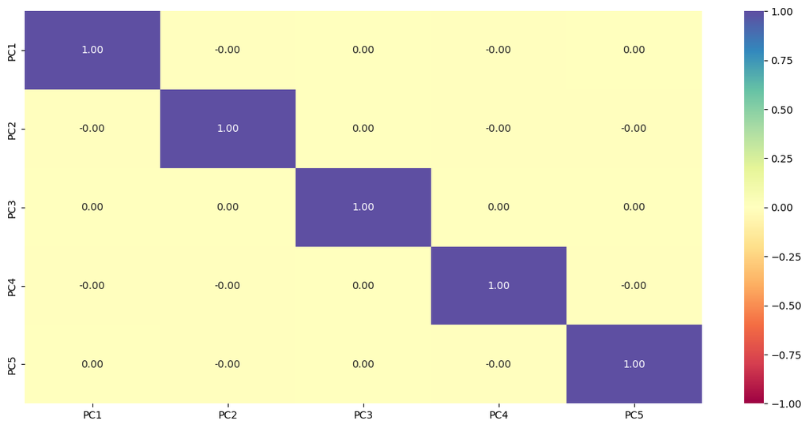

```python
plt.figure(figsize=(15, 7))
sns.heatmap(
    pca5_df.corr(), annot=True, vmin=-1, vmax=1, fmt=".2f", cmap="Spectral"
)
plt.show()
```

#### After performing PCA, it becomes evident that the variables are entirely uncorrelated with each other.

### Performing the elbow method to determine the numebr of k-means clusters.

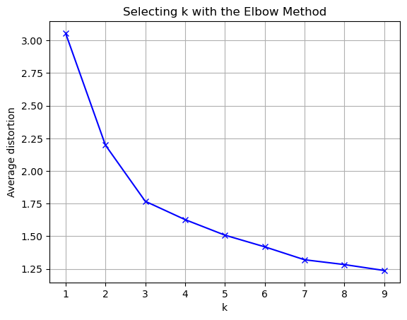

```python
clusters = range(1, 10)
meanDistortions = []

for k in clusters:
    model = KMeans(n_clusters=k, random_state=2)
    model.fit(pca5_df)
    prediction = model.predict(pca5_df)
    distortion = (
        sum(
            np.min(cdist(pca5_df, model.cluster_centers_, "euclidean"), axis=1)
        )
        / pca5_df.shape[0]
    )

    meanDistortions.append(distortion)

    #print("Number of Clusters:", k, "\tAverage Distortion:", distortion)

plt.plot(clusters, meanDistortions, "bx-")
plt.xlabel("k")
plt.ylabel("Average distortion")
plt.title("Selecting k with the Elbow Method")
plt.grid(True)
plt.show()
```

```python
silhouette_coefficients = []
for k in range (2, 11):
    kmeans = KMeans (n_clusters = k, random_state=2)
    kmeans.fit (pca5_df)
    score = silhouette_score (pca5_df, kmeans.labels_)
    silhouette_coefficients.append (score)
```

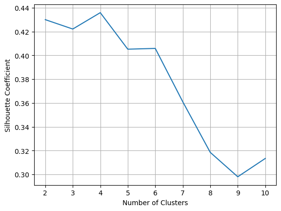

```python
# Plotting the results:
plt.plot (range (2, 11), silhouette_coefficients)
plt.xticks (range (2, 11))
plt.xlabel ("Number of Clusters")
plt.ylabel ("Silhouette Coefficient")
plt.grid(True)
plt.show ()
```

```python
# Create a KMeans object with 4 clusters
kmeans_pca = KMeans(n_clusters=4, random_state=1)

# Fit the KMeans algorithm on the PCA-transformed data
kmeans_pca.fit(pca5_df)

# Assign cluster labels to the PCA scores
pca5_df["PCA_kmeans_clusters"] = kmeans_pca.labels_
```

```python
pca5_df.head()
```

|  | PC1 | PC2 | PC3 | PC4 | PC5 | PCA_kmeans_clusters |
| --- | --- | --- | --- | --- | --- | --- |
| 0 | -1.993135 | -0.656612 | 0.873653 | 0.640678 | 0.646045 | 1 |
| 1 | -1.253957 | -1.352185 | 0.299849 | -0.221077 | 0.508773 | 1 |
| 2 | -2.292032 | -0.486156 | 1.336114 | -1.014833 | 0.502814 | 2 |
| 3 | -2.870426 | 0.392986 | 0.273140 | -1.057376 | 0.116365 | 3 |
| 4 | -2.799402 | 0.466724 | 0.520538 | -1.009465 | 0.170139 | 2 |

```python
pca5_df.PCA_kmeans_clusters.value_counts ()
```

```
1    210
0    167
3     88
2     41
Name: PCA_kmeans_clusters, dtype: int64
```